# Summary

## Summary of Political Stances Experiment and Text Analysis

### Why Does Political Stance-Taking Matter as a Business Concern?

Over the past decade, companies and firm decision makers have begun taking public political stances at a staggering rate. From the conservative owners of [Chic-Fil-A](https://www.cnbc.com/2019/04/02/chick-fil-a-loses-two-airport-deals-in-less-than-two-weeks.html) to the liberal owner of [Penzey's Spices](https://www.newyorker.com/culture/annals-of-gastronomy/ceo-who-called-trump-racist-penzeys-spice-mix), CEOs and other firm decision makers are taking stances that impact their firms' [brand image](https://journals.sagepub.com/doi/full/10.1177/1086026619848144?casa_token=26JiUcwzsmMAAAAA%3AZQ2hRkWuXYKSL6qtODmD7-9dF1WYdxo3S0-n6ttX-fg4zw6vMJu9sFjZ4AsSD2pc8TuSNpIyHIE), [employee motivation](https://pubsonline.informs.org/doi/abs/10.1287/mnsc.2019.3562), and consumer demand.

While research and real-world examples show that stance-taking has serious implications for the bottom line, less systematic evidence exists on how firm decision makers strategize with respect to stance-taking. Do they always take stances that will yield higher profits for themselves and for the firm? How much do an individual's own beliefs and values matter in this decision? Can we isolate these factors to show their relative causal impacts on decision making?

This research project aims to understand the factors behind why individual decision makers take political stances in their day-to-day business. By learning more about who takes stances and why, this project aims to better inform corporate decision makers of the dangers and opportunities from taking political stances. It also provides guidance to boards of directors looking to create governance rules around political stance-taking.

### Experimental Design

In this experiment, I investigate causal factors behind why firm decision makers might take a political stance as part of a business strategy. As a baseline, I focus specifically on:

1. The match between decision maker beliefs and political causes
2. The monetary payoffs from stance-taking in niche markets
3. External factors that might constrain or enable stance-taking, such as activist pressure.

As an extension, I also investigate heterogeneous effects by individuals' political and ethical orientations.

The experimental design was inspired by [Ederer and Manso (2013, ManSci)](https://pubsonline.informs.org/doi/abs/10.1287/mnsc.1120.1683?journalCode=mnsc), who examine the impact of incentives on innovation activity. It is a strategy exploration simulation, in which participants serve as the CEO of a hypothetical company and are asked to choose inputs for a product.

Each bundle of inputs is associated with an unknown profit outcome. Participants explore the landscape of input combinations to try to increase their profits. Below is an example round of the game with associated payoffs.

[video not shown]

To guide their exploration, I gave participants two reference strategies and showed the associated profits. The first reference strategy was provided at the beginning of the experiment and showed a strategy that did not involve taking a political stance. After submitting five input bundles and learning their associated profits, participants then observed a second reference strategy (in the form of market research) that involved taking a political stance. This market research hinted at higher monetary benefits from taking a political stance within a certain market niche.

Participants then submitted five more input bundles and learned associated profits in each of the five remaining periods. Finally, they answered demographic questions, questions about their ethical and political beliefs, and questions about how they made their strategies during the game.

I ran this study in the summer of 2020 on Prolific, an academic-oriented online platform for subject recruitment. Participants in this study were Americans who self-identified as social conservatives or social liberals. The political causes centered on gun control, which Gallup identified in 2018 as one of the most starkly polarizing issues between Republicans and Democrats. Participants were randomly assigned the opportunity to donate to a social liberal cause ([Everytown for Gun Safety](https://www.everytown.org/)), a social conservative cause ([the National Rifle Association](https://www.nrafoundation.org/)), or a “placebo”, apolitical cause ([the American Red Cross](https://www.redcross.org/)).

In the study, taking a stance involved donating 10% of earnings to the cause. Earnings were paid out to participants and donations were sent in bulk to the causes after the experiment had ended. Due to these real stakes, participants were incentivized to take both the personal payoffs and costly stances seriously. To allow for testing of external constraints, I ran one additional study in which future profitability fell when participants switched stances, representing credible threats from activists who seek to punish firms that “flip flop” on stances.

## Findings

Below is an abbreviated summary statistics table that shows feature means, broken down by political orientation (the *liberal* variable).

There are several hints that participants truthfully answer Prolific's political orientation screening question. First, participants who describe themselves as liberal on Prolific are much more likely to describe themselves as liberal in the experiment, and vice versa. Second, differences in demographic means also align with overall US population differences on this dimension. For example, conservatives in the experiment are older, whiter, and more likely to be male. Finally, conservatives in the experiment are hold conservative beliefs on certain issues; they are more likely to believe in the fairness of the free market and believe that stance taking and social responsibility are less appropriate in business.

|  | Conservative | Liberal | Diff (Lib - Cons) | Diff P-Vals |
| --- | --- | --- | --- | --- |
| Stance in Round | 0.507000 | 0.553795 | 0.046795 | 7.424373e-02 |
| Earnings in Round | 25.955067 | 26.581518 | 0.626452 | 3.121530e-01 |
| Age | 36.285235 | 29.622074 | -6.663161 | 1.467525e-11 |
| Male | 0.600000 | 0.368771 | -0.231229 | 1.111341e-08 |
| White | 0.772881 | 0.617940 | -0.154941 | 3.586351e-05 |
| Black | 0.067797 | 0.066445 | -0.001351 | 9.475535e-01 |
| Hispanic | 0.044068 | 0.073090 | 0.029022 | 1.314479e-01 |
| Asian | 0.066667 | 0.155116 | 0.088449 | 5.215275e-04 |
| Other Race | 0.046667 | 0.085809 | 0.039142 | 5.330586e-02 |
| Volunteer Prev Yr | 0.447811 | 0.470000 | 0.022189 | 5.871907e-01 |
| Donated Prev Yr | 0.696246 | 0.697674 | 0.001429 | 9.698475e-01 |
| Social Liberal (1-5) | 1.182432 | 4.288079 | 3.105647 | 9.421085e-177 |
| Fair Market (-5 to 5) | 1.217544 | -1.005461 | -2.223005 | 1.004926e-56 |
| CEO Stance Approp | 2.469799 | 3.721854 | 1.252056 | 3.340338e-29 |
| Firm CSR Approp | 2.811448 | 4.039735 | 1.228287 | 2.760307e-28 |
| Outcome Ethics | 0.684564 | 0.770764 | 0.086200 | 1.781135e-02 |
| Risk Averse (1 to 5) | 2.390845 | 2.379791 | -0.011054 | 9.129161e-01 |
| Ambiguity Averse (1 to 5) | 3.505455 | 3.373239 | -0.132215 | 2.251159e-01 |

I next present two graphs showing the effects of monetary incentives and match/mismatch between the decision maker's beliefs and the political cause. The Y-axes are “Percent Taking a Stance” and “Earnings”, respectively, and the X-axis is the experimental round. The error regions around the lines represent 95% confidence intervals. I’ve put a dashed red line before round 6 to show when participants see the second reference point revealing higher profits from taking a stance. In the left graph, we see that stance taking jumps for all groups after this second reference point, and that the non-political and matched conditions take stances at about the same rate.

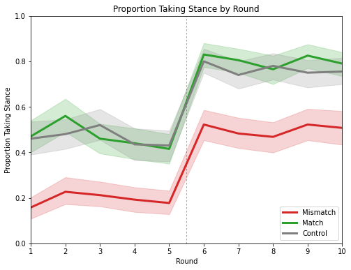

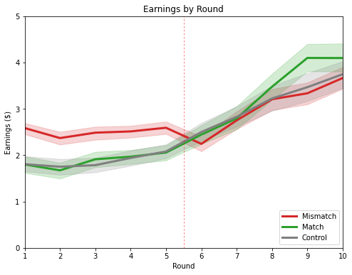

In the second study, I find that external constraints can shape stance-taking strategies. In this graph, the Y-axis is the cumulative number of stance switches. In this experiment, credible threats to punish “flip-flopping” on stances results in more consistent stance taking over time.

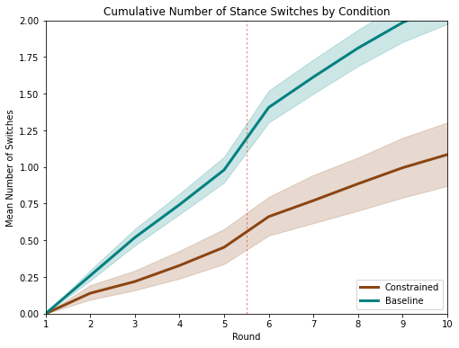

Beyond these baseline findings, I find interesting differences in how decision makers with different political and ethical orientations approach stance-taking. For example, social liberals tend to take more stances than social conservatives in the matched cause condition and fewer stances in the mismatched cause condition. Social conservatives in this study tend not to change their stance-taking behavior in relation to the political orientation of the cause.

Taken together, this suggests that liberals may be more “reactive” to stance-taking.

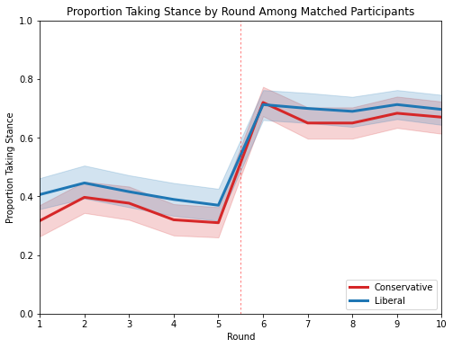

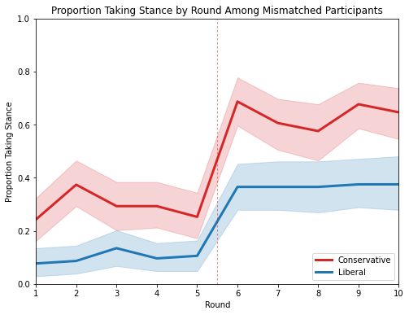

Digging a bit deeper, I analyzed participant “open” text responses to how they strategized with respect to stance taking. Using a simple logistical classification model of unigrams and bigrams, I find that mismatched liberals were much more likely to mention the cause and the act of donation (e.g., "nra", "refused", "donated") than mismatched conservatives, who were more likely to not respond to the question ("empty") or focus more on the end goals of profitability (e.g., "maximize", "profitable", "positive").

Taken together, these results suggest that liberals see the act of stance-taking as a way to take a stance reflecting their principles in the name of the firm, whereas conservatives tend to care less about the content of the stance and focus more on stance-taking to achieve the firm’s profit mandate. This aligns with [existing research](https://onlinelibrary.wiley.com/doi/full/10.1002/smj.2550?casa_token=PSseaaLMf2kAAAAA%3ATx6dxcg8_4quIf9bdjhNgjHGuP7l9dUMMqoHiHe8ea6Aq2dfwdiKF9yV5c0UltomE3US9Kp2qtWD) showing that firms with more liberal employees tend to engage in more corporate social responsibility initiatives.

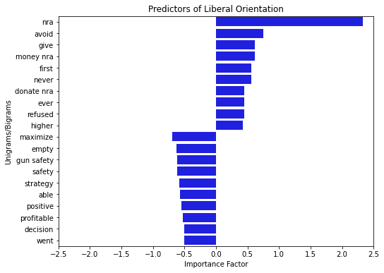

I also find that mismatched participants who tend to judge the [ethicality of their actions by their outcomes](https://www.bbc.co.uk/ethics/introduction/consequentialism_1.shtml) tend to take more stances and earn more than those who tend to judge [ethicality by a prescribed set of rules](https://www.bbc.co.uk/ethics/introduction/duty_1.shtml). The table below shows a series of regressions of ethical outlook on performance.[1]

These ethics-based effects on earnings and stance taking among the mismatched are about 50% of the size of the effects from political mismatch in the full sample.

|  | *Dependent variable:* |  |  |  |
| --- | --- | --- | --- | --- |
|  | Earnings in Round |  |  |  |
|  | (1) | (2) | (3) | (4) |
| Outcome-Based Ethics | -0.018 | -0.018 | -0.248*** | -0.172*** |
|  | (0.061) | (0.061) | (0.060) | (0.057) |
| 2nd Half |  | 0.531*** | 0.184* | 0.258*** |
|  |  | (0.060) | (0.097) | (0.095) |
| Outcome-Based Ethics x 2nd Half |  |  | 0.461*** | 0.545*** |
|  |  |  | (0.121) | (0.122) |
| Constant | 2.786*** | 2.521*** | 2.694*** | 2.917*** |
|  | (0.049) | (0.052) | (0.046) | (0.165) |
| Controls |  |  |  | X |
| Observations | 2,010 | 2,010 | 2,010 | 1,760 |
| Adjusted R<sup>2</sup> | 0.0005 | 0.037 | 0.042 | 0.056 |
| *Note:* | *p<0.1; **p<0.05; ***p<0.01 |  |  |  |

### Conclusion and Recommendations

The choice to take a political stance at work involves a complex mix of factors, and the analyses above show that multiple factors causally impact this high stakes decision. Moreover, liberals and conservatives, and those with different ethical outlooks, view stance-taking in different ways.

There can be massive financial implications for taking (or not taking) certain political stances. On a practical level, this research provides guideposts for firms who are looking to manage this critical aspect of their firm's non-market strategy, especially with respect to their executive decision makers. For example, when choosing a new CEO, firms should understand that CEO political and ethical beliefs will likely *causally* impact their approaches to stance-taking. Firms can also use this work to justify governance structures that may constrain or enable stance-taking in the workplace.

#### Footnotes

[1]: Ethical outlook was operationalized as a binary variable, with 0 representing rule-based ethics and 1 representing outcome-based ethics. *2nd Half* is a binary feature, taking 1 if in rounds 6-10. Controls include participant age, gender, race, volunteer and donation activity within the past year, political orientation, beliefs in the fairness of capitalism, opinions on stance-taking and corporate social initiatives, and risk and ambiguity aversion. All regression models were fit using ordinary least squares with heteroskedasticity-robust standard errors with degree-of-freedom correction *(n-1) / (n-k)*, where n is number of observations and k is the number of features. Errors were clustered at the participant level. ↩